# Risk Factor Analysis

## Outcome Variable

**Outcome Variable:** ever_sstunted

## Predictor Variables

**Intervention Variable:** feducyrs

**Adjustment Set:**

- arm
- W_mage
- meducyrs
- hhwealth_quart
- W_mhtcm
- W_mwtkg
- W_mbmi
- W_gagebrth
- W_birthwt
- W_birthlen
- single
- delta_W_mage
- delta_meducyrs
- delta_hhwealth_quart
- delta_W_mhtcm
- delta_W_mwtkg
- delta_W_mbmi
- delta_W_gagebrth
- delta_W_birthwt
- delta_W_birthlen
- delta_single

## Stratifying Variables

The analysis was stratified on these variable(s):

- agecat
- studyid
- country

## Data Summary

| agecat | studyid | country | feducyrs | ever_sstunted | n_cell | n |
| --- | --- | --- | --- | --- | --- | --- |
| 0-24 months | ki0047075b-MAL-ED | BANGLADESH | High | 0 | 47 | 149 |
| 0-24 months | ki0047075b-MAL-ED | BANGLADESH | High | 1 | 7 | 149 |
| 0-24 months | ki0047075b-MAL-ED | BANGLADESH | Low | 0 | 32 | 149 |
| 0-24 months | ki0047075b-MAL-ED | BANGLADESH | Low | 1 | 8 | 149 |
| 0-24 months | ki0047075b-MAL-ED | BANGLADESH | Medium | 0 | 39 | 149 |
| 0-24 months | ki0047075b-MAL-ED | BANGLADESH | Medium | 1 | 16 | 149 |
| 0-24 months | ki0047075b-MAL-ED | INDIA | High | 0 | 37 | 147 |
| 0-24 months | ki0047075b-MAL-ED | INDIA | High | 1 | 7 | 147 |
| 0-24 months | ki0047075b-MAL-ED | INDIA | Low | 0 | 44 | 147 |
| 0-24 months | ki0047075b-MAL-ED | INDIA | Low | 1 | 15 | 147 |
| 0-24 months | ki0047075b-MAL-ED | INDIA | Medium | 0 | 36 | 147 |
| 0-24 months | ki0047075b-MAL-ED | INDIA | Medium | 1 | 8 | 147 |
| 0-24 months | ki0047075b-MAL-ED | NEPAL | High | 0 | 39 | 98 |
| 0-24 months | ki0047075b-MAL-ED | NEPAL | High | 1 | 3 | 98 |
| 0-24 months | ki0047075b-MAL-ED | NEPAL | Low | 0 | 26 | 98 |
| 0-24 months | ki0047075b-MAL-ED | NEPAL | Low | 1 | 2 | 98 |
| 0-24 months | ki0047075b-MAL-ED | NEPAL | Medium | 0 | 24 | 98 |
| 0-24 months | ki0047075b-MAL-ED | NEPAL | Medium | 1 | 4 | 98 |
| 0-24 months | ki0047075b-MAL-ED | PERU | High | 0 | 98 | 250 |
| 0-24 months | ki0047075b-MAL-ED | PERU | High | 1 | 22 | 250 |
| 0-24 months | ki0047075b-MAL-ED | PERU | Low | 0 | 53 | 250 |
| 0-24 months | ki0047075b-MAL-ED | PERU | Low | 1 | 16 | 250 |
| 0-24 months | ki0047075b-MAL-ED | PERU | Medium | 0 | 49 | 250 |
| 0-24 months | ki0047075b-MAL-ED | PERU | Medium | 1 | 12 | 250 |
| 0-24 months | ki0047075b-MAL-ED | SOUTH AFRICA | High | 0 | 35 | 110 |
| 0-24 months | ki0047075b-MAL-ED | SOUTH AFRICA | High | 1 | 8 | 110 |
| 0-24 months | ki0047075b-MAL-ED | SOUTH AFRICA | Low | 0 | 30 | 110 |
| 0-24 months | ki0047075b-MAL-ED | SOUTH AFRICA | Low | 1 | 7 | 110 |
| 0-24 months | ki0047075b-MAL-ED | SOUTH AFRICA | Medium | 0 | 20 | 110 |
| 0-24 months | ki0047075b-MAL-ED | SOUTH AFRICA | Medium | 1 | 10 | 110 |

[output cut: 210 more lines]

The following strata were considered:

- agecat: 0-24 months, studyid: ki0047075b-MAL-ED, country: BANGLADESH
- agecat: 0-24 months, studyid: ki0047075b-MAL-ED, country: INDIA
- agecat: 0-24 months, studyid: ki0047075b-MAL-ED, country: NEPAL
- agecat: 0-24 months, studyid: ki0047075b-MAL-ED, country: PERU
- agecat: 0-24 months, studyid: ki0047075b-MAL-ED, country: SOUTH AFRICA
- agecat: 0-24 months, studyid: ki0047075b-MAL-ED, country: TANZANIA, UNITED REPUBLIC OF
- agecat: 0-24 months, studyid: ki1000304b-SAS-CompFeed, country: INDIA
- agecat: 0-24 months, studyid: ki1000304b-SAS-FoodSuppl, country: INDIA
- agecat: 0-24 months, studyid: ki1017093b-PROVIDE, country: BANGLADESH
- agecat: 0-24 months, studyid: ki1017093c-NIH-Crypto, country: BANGLADESH
- agecat: 0-24 months, studyid: ki1066203-TanzaniaChild2, country: TANZANIA, UNITED REPUBLIC OF
- agecat: 0-24 months, studyid: ki1113344-GMS-Nepal, country: NEPAL
- agecat: 0-24 months, studyid: ki1119695-PROBIT, country: BELARUS
- agecat: 0-24 months, studyid: ki1126311-ZVITAMBO, country: ZIMBABWE
- agecat: 0-24 months, studyid: ki1135781-COHORTS, country: GUATEMALA
- agecat: 0-24 months, studyid: ki1135781-COHORTS, country: INDIA
- agecat: 0-24 months, studyid: ki1135781-COHORTS, country: PHILIPPINES
- agecat: 0-24 months, studyid: ki1148112-LCNI-5, country: MALAWI
- agecat: 0-24 months, studyid: kiGH5241-JiVitA-3, country: BANGLADESH
- agecat: 0-24 months, studyid: kiGH5241-JiVitA-4, country: BANGLADESH
- agecat: 0-6 months, studyid: ki0047075b-MAL-ED, country: BANGLADESH
- agecat: 0-6 months, studyid: ki0047075b-MAL-ED, country: INDIA
- agecat: 0-6 months, studyid: ki0047075b-MAL-ED, country: NEPAL
- agecat: 0-6 months, studyid: ki0047075b-MAL-ED, country: PERU
- agecat: 0-6 months, studyid: ki0047075b-MAL-ED, country: SOUTH AFRICA
- agecat: 0-6 months, studyid: ki0047075b-MAL-ED, country: TANZANIA, UNITED REPUBLIC OF
- agecat: 0-6 months, studyid: ki1000304b-SAS-CompFeed, country: INDIA
- agecat: 0-6 months, studyid: ki1000304b-SAS-FoodSuppl, country: INDIA
- agecat: 0-6 months, studyid: ki1017093b-PROVIDE, country: BANGLADESH
- agecat: 0-6 months, studyid: ki1017093c-NIH-Crypto, country: BANGLADESH
- agecat: 0-6 months, studyid: ki1066203-TanzaniaChild2, country: TANZANIA, UNITED REPUBLIC OF
- agecat: 0-6 months, studyid: ki1113344-GMS-Nepal, country: NEPAL
- agecat: 0-6 months, studyid: ki1119695-PROBIT, country: BELARUS
- agecat: 0-6 months, studyid: ki1126311-ZVITAMBO, country: ZIMBABWE
- agecat: 0-6 months, studyid: ki1135781-COHORTS, country: GUATEMALA
- agecat: 0-6 months, studyid: ki1135781-COHORTS, country: INDIA
- agecat: 0-6 months, studyid: ki1135781-COHORTS, country: PHILIPPINES
- agecat: 0-6 months, studyid: ki1148112-LCNI-5, country: MALAWI
- agecat: 0-6 months, studyid: kiGH5241-JiVitA-3, country: BANGLADESH
- agecat: 0-6 months, studyid: kiGH5241-JiVitA-4, country: BANGLADESH

### Dropped Strata

Some strata were dropped due to rare outcomes:

- agecat: 0-24 months, studyid: ki0047075b-MAL-ED, country: NEPAL
- agecat: 0-6 months, studyid: ki0047075b-MAL-ED, country: BANGLADESH
- agecat: 0-6 months, studyid: ki0047075b-MAL-ED, country: INDIA
- agecat: 0-6 months, studyid: ki0047075b-MAL-ED, country: NEPAL
- agecat: 0-6 months, studyid: ki0047075b-MAL-ED, country: SOUTH AFRICA
- agecat: 0-6 months, studyid: ki0047075b-MAL-ED, country: TANZANIA, UNITED REPUBLIC OF
- agecat: 0-6 months, studyid: ki1148112-LCNI-5, country: MALAWI

## Methods Detail

We’re interested in the causal parameters $E[Y_a]$ for all values of $a \in \mathcal{A}$. These parameters represent the mean outcome if, possibly contrary to fact, we intervened to set all units to have $A=a$. Under the randomization and positivity assumptions, these are identified by the statistical parameters $\psi_a=E_W[E_{Y|A,W}(Y|A=a,W)]$. In addition, we’re interested in the mean of $Y$, $E[Y]$ under no intervention (the observed mean). We will estimate these parameters by using SuperLearner to fit the relevant likelihood factors – $E_{Y|A,W}(Y|A=a,W)$ and $p(A=a|W)$, and then updating our likelihood fit using a joint TMLE.

For unadjusted analyses ($W=\{\}$), initial likelihoods were estimated using Lrnr_glm to estimate the simple $E(Y|A)$ and Lrnr_mean to estimate $p(A)$. For adjusted analyses, a small library containing Lrnr_glmnet, Lrnr_xgboost, and Lrnr_mean was used.

Having estimated these parameters, we will then use the delta method to estimate relative risks and attributable risks relative to a prespecified baseline level of $A$.

# Results Detail

## Results Plots

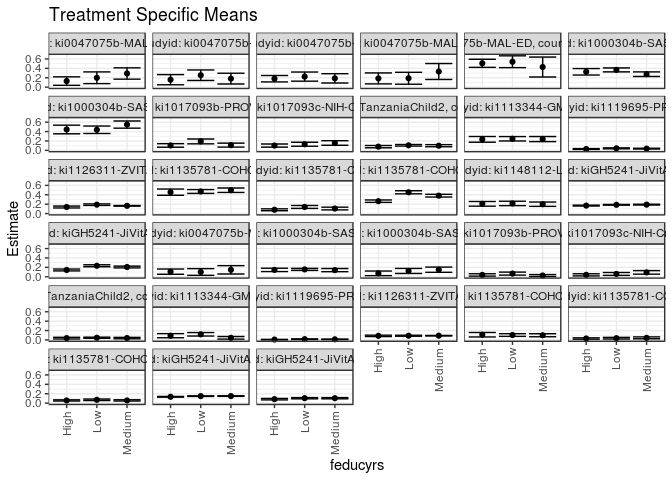

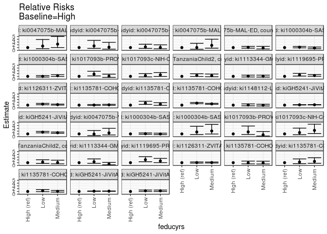

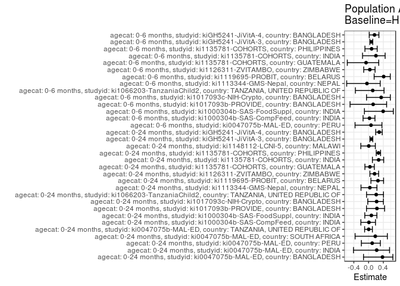

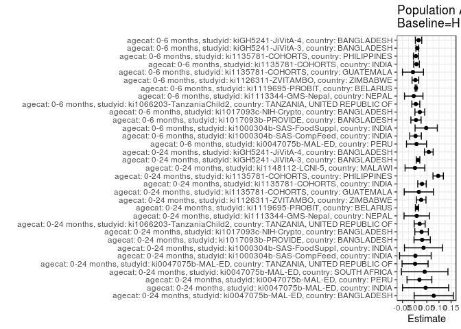

## Results Table

### Parameter: TSM

| agecat | studyid | country | intervention_level | baseline_level | estimate | ci_lower | ci_upper |
| --- | --- | --- | --- | --- | --- | --- | --- |
| 0-24 months | ki0047075b-MAL-ED | BANGLADESH | High | NA | 0.1296296 | 0.0397383 | 0.2195209 |
| 0-24 months | ki0047075b-MAL-ED | BANGLADESH | Low | NA | 0.2000000 | 0.0756229 | 0.3243771 |
| 0-24 months | ki0047075b-MAL-ED | BANGLADESH | Medium | NA | 0.2909091 | 0.1704725 | 0.4113457 |
| 0-24 months | ki0047075b-MAL-ED | INDIA | High | NA | 0.1590909 | 0.0506480 | 0.2675338 |
| 0-24 months | ki0047075b-MAL-ED | INDIA | Low | NA | 0.2542373 | 0.1427503 | 0.3657243 |
| 0-24 months | ki0047075b-MAL-ED | INDIA | Medium | NA | 0.1818182 | 0.0674652 | 0.2961712 |
| 0-24 months | ki0047075b-MAL-ED | PERU | High | NA | 0.1804278 | 0.1123835 | 0.2484722 |
| 0-24 months | ki0047075b-MAL-ED | PERU | Low | NA | 0.2249833 | 0.1274586 | 0.3225080 |
| 0-24 months | ki0047075b-MAL-ED | PERU | Medium | NA | 0.1875523 | 0.0885422 | 0.2865624 |
| 0-24 months | ki0047075b-MAL-ED | SOUTH AFRICA | High | NA | 0.1860465 | 0.0692022 | 0.3028908 |
| 0-24 months | ki0047075b-MAL-ED | SOUTH AFRICA | Low | NA | 0.1891892 | 0.0624128 | 0.3159655 |
| 0-24 months | ki0047075b-MAL-ED | SOUTH AFRICA | Medium | NA | 0.3333333 | 0.1638745 | 0.5027922 |
| 0-24 months | ki0047075b-MAL-ED | TANZANIA, UNITED REPUBLIC OF | High | NA | 0.5076923 | 0.4215490 | 0.5938357 |
| 0-24 months | ki0047075b-MAL-ED | TANZANIA, UNITED REPUBLIC OF | Low | NA | 0.5409836 | 0.4156360 | 0.6663312 |
| 0-24 months | ki0047075b-MAL-ED | TANZANIA, UNITED REPUBLIC OF | Medium | NA | 0.4285714 | 0.2164143 | 0.6407286 |
| 0-24 months | ki1000304b-SAS-CompFeed | INDIA | High | NA | 0.3271287 | 0.2582173 | 0.3960401 |
| 0-24 months | ki1000304b-SAS-CompFeed | INDIA | Low | NA | 0.3673677 | 0.3256281 | 0.4091073 |
| 0-24 months | ki1000304b-SAS-CompFeed | INDIA | Medium | NA | 0.2763562 | 0.2278533 | 0.3248592 |
| 0-24 months | ki1000304b-SAS-FoodSuppl | INDIA | High | NA | 0.4443476 | 0.3526117 | 0.5360836 |
| 0-24 months | ki1000304b-SAS-FoodSuppl | INDIA | Low | NA | 0.4379943 | 0.3586402 | 0.5173484 |
| 0-24 months | ki1000304b-SAS-FoodSuppl | INDIA | Medium | NA | 0.5483641 | 0.4718469 | 0.6248814 |
| 0-24 months | ki1017093b-PROVIDE | BANGLADESH | High | NA | 0.1048819 | 0.0671883 | 0.1425755 |
| 0-24 months | ki1017093b-PROVIDE | BANGLADESH | Low | NA | 0.1904898 | 0.1390740 | 0.2419056 |
| 0-24 months | ki1017093b-PROVIDE | BANGLADESH | Medium | NA | 0.1116524 | 0.0695591 | 0.1537457 |
| 0-24 months | ki1017093c-NIH-Crypto | BANGLADESH | High | NA | 0.1021438 | 0.0688516 | 0.1354360 |
| 0-24 months | ki1017093c-NIH-Crypto | BANGLADESH | Low | NA | 0.1300559 | 0.0880720 | 0.1720399 |
| 0-24 months | ki1017093c-NIH-Crypto | BANGLADESH | Medium | NA | 0.1568120 | 0.1082013 | 0.2054227 |
| 0-24 months | ki1066203-TanzaniaChild2 | TANZANIA, UNITED REPUBLIC OF | High | NA | 0.0788465 | 0.0544226 | 0.1032704 |
| 0-24 months | ki1066203-TanzaniaChild2 | TANZANIA, UNITED REPUBLIC OF | Low | NA | 0.1074965 | 0.0903053 | 0.1246878 |
| 0-24 months | ki1066203-TanzaniaChild2 | TANZANIA, UNITED REPUBLIC OF | Medium | NA | 0.0989038 | 0.0763438 | 0.1214638 |

[output cut: 69 more lines]

### Parameter: E(Y)

| agecat | studyid | country | intervention_level | baseline_level | estimate | ci_lower | ci_upper |
| --- | --- | --- | --- | --- | --- | --- | --- |
| 0-24 months | ki0047075b-MAL-ED | BANGLADESH | NA | NA | 0.2080537 | 0.1426574 | 0.2734499 |
| 0-24 months | ki0047075b-MAL-ED | INDIA | NA | NA | 0.2040816 | 0.1387072 | 0.2694561 |
| 0-24 months | ki0047075b-MAL-ED | PERU | NA | NA | 0.2000000 | 0.1503169 | 0.2496831 |
| 0-24 months | ki0047075b-MAL-ED | SOUTH AFRICA | NA | NA | 0.2272727 | 0.1486005 | 0.3059450 |
| 0-24 months | ki0047075b-MAL-ED | TANZANIA, UNITED REPUBLIC OF | NA | NA | 0.5094340 | 0.4419812 | 0.5768867 |
| 0-24 months | ki1000304b-SAS-CompFeed | INDIA | NA | NA | 0.3300654 | 0.3020915 | 0.3580392 |
| 0-24 months | ki1000304b-SAS-FoodSuppl | INDIA | NA | NA | 0.4808612 | 0.4329065 | 0.5288160 |
| 0-24 months | ki1017093b-PROVIDE | BANGLADESH | NA | NA | 0.1357143 | 0.1103250 | 0.1611036 |
| 0-24 months | ki1017093c-NIH-Crypto | BANGLADESH | NA | NA | 0.1306069 | 0.1066024 | 0.1546113 |
| 0-24 months | ki1066203-TanzaniaChild2 | TANZANIA, UNITED REPUBLIC OF | NA | NA | 0.0994545 | 0.0874362 | 0.1114727 |
| 0-24 months | ki1113344-GMS-Nepal | NEPAL | NA | NA | 0.2428161 | 0.2109378 | 0.2746944 |
| 0-24 months | ki1119695-PROBIT | BELARUS | NA | NA | 0.0382494 | 0.0300114 | 0.0464873 |
| 0-24 months | ki1126311-ZVITAMBO | ZIMBABWE | NA | NA | 0.1660581 | 0.1598251 | 0.1722911 |
| 0-24 months | ki1135781-COHORTS | GUATEMALA | NA | NA | 0.4728000 | 0.4451119 | 0.5004881 |
| 0-24 months | ki1135781-COHORTS | INDIA | NA | NA | 0.1105736 | 0.0944098 | 0.1267374 |
| 0-24 months | ki1135781-COHORTS | PHILIPPINES | NA | NA | 0.3600694 | 0.3425352 | 0.3776037 |
| 0-24 months | ki1148112-LCNI-5 | MALAWI | NA | NA | 0.2078721 | 0.1799617 | 0.2357825 |
| 0-24 months | kiGH5241-JiVitA-3 | BANGLADESH | NA | NA | 0.1828613 | 0.1771578 | 0.1885648 |
| 0-24 months | kiGH5241-JiVitA-4 | BANGLADESH | NA | NA | 0.2024261 | 0.1900868 | 0.2147654 |
| 0-6 months | ki0047075b-MAL-ED | PERU | NA | NA | 0.1160000 | 0.0762256 | 0.1557744 |
| 0-6 months | ki1000304b-SAS-CompFeed | INDIA | NA | NA | 0.1493124 | 0.1303783 | 0.1682465 |
| 0-6 months | ki1000304b-SAS-FoodSuppl | INDIA | NA | NA | 0.1201923 | 0.0889059 | 0.1514788 |
| 0-6 months | ki1017093b-PROVIDE | BANGLADESH | NA | NA | 0.0442857 | 0.0290345 | 0.0595370 |
| 0-6 months | ki1017093c-NIH-Crypto | BANGLADESH | NA | NA | 0.0620053 | 0.0448256 | 0.0791849 |
| 0-6 months | ki1066203-TanzaniaChild2 | TANZANIA, UNITED REPUBLIC OF | NA | NA | 0.0432228 | 0.0350563 | 0.0513894 |
| 0-6 months | ki1113344-GMS-Nepal | NEPAL | NA | NA | 0.0862069 | 0.0653403 | 0.1070734 |
| 0-6 months | ki1119695-PROBIT | BELARUS | NA | NA | 0.0137339 | 0.0103297 | 0.0171381 |
| 0-6 months | ki1126311-ZVITAMBO | ZIMBABWE | NA | NA | 0.0901382 | 0.0853389 | 0.0949375 |
| 0-6 months | ki1135781-COHORTS | GUATEMALA | NA | NA | 0.1039216 | 0.0851851 | 0.1226580 |
| 0-6 months | ki1135781-COHORTS | INDIA | NA | NA | 0.0380014 | 0.0280567 | 0.0479461 |
| 0-6 months | ki1135781-COHORTS | PHILIPPINES | NA | NA | 0.0618056 | 0.0530095 | 0.0706016 |
| 0-6 months | kiGH5241-JiVitA-3 | BANGLADESH | NA | NA | 0.1460777 | 0.1409301 | 0.1512254 |
| 0-6 months | kiGH5241-JiVitA-4 | BANGLADESH | NA | NA | 0.1008032 | 0.0917342 | 0.1098723 |

### Parameter: RR

| agecat | studyid | country | intervention_level | baseline_level | estimate | ci_lower | ci_upper |
| --- | --- | --- | --- | --- | --- | --- | --- |
| 0-24 months | ki0047075b-MAL-ED | BANGLADESH | High | High | 1.0000000 | 1.0000000 | 1.000000 |
| 0-24 months | ki0047075b-MAL-ED | BANGLADESH | Low | High | 1.5428571 | 0.6078543 | 3.916084 |
| 0-24 months | ki0047075b-MAL-ED | BANGLADESH | Medium | High | 2.2441558 | 1.0006999 | 5.032713 |
| 0-24 months | ki0047075b-MAL-ED | INDIA | High | High | 1.0000000 | 1.0000000 | 1.000000 |
| 0-24 months | ki0047075b-MAL-ED | INDIA | Low | High | 1.5980630 | 0.7105469 | 3.594140 |
| 0-24 months | ki0047075b-MAL-ED | INDIA | Medium | High | 1.1428571 | 0.4520604 | 2.889265 |
| 0-24 months | ki0047075b-MAL-ED | PERU | High | High | 1.0000000 | 1.0000000 | 1.000000 |
| 0-24 months | ki0047075b-MAL-ED | PERU | Low | High | 1.2469434 | 0.7006328 | 2.219233 |
| 0-24 months | ki0047075b-MAL-ED | PERU | Medium | High | 1.0394866 | 0.5434795 | 1.988175 |
| 0-24 months | ki0047075b-MAL-ED | SOUTH AFRICA | High | High | 1.0000000 | 1.0000000 | 1.000000 |
| 0-24 months | ki0047075b-MAL-ED | SOUTH AFRICA | Low | High | 1.0168919 | 0.4058970 | 2.547614 |
| 0-24 months | ki0047075b-MAL-ED | SOUTH AFRICA | Medium | High | 1.7916667 | 0.7986258 | 4.019491 |
| 0-24 months | ki0047075b-MAL-ED | TANZANIA, UNITED REPUBLIC OF | High | High | 1.0000000 | 1.0000000 | 1.000000 |
| 0-24 months | ki0047075b-MAL-ED | TANZANIA, UNITED REPUBLIC OF | Low | High | 1.0655738 | 0.7995761 | 1.420062 |
| 0-24 months | ki0047075b-MAL-ED | TANZANIA, UNITED REPUBLIC OF | Medium | High | 0.8441558 | 0.5002121 | 1.424594 |
| 0-24 months | ki1000304b-SAS-CompFeed | INDIA | High | High | 1.0000000 | 1.0000000 | 1.000000 |
| 0-24 months | ki1000304b-SAS-CompFeed | INDIA | Low | High | 1.1230066 | 0.8963942 | 1.406908 |
| 0-24 months | ki1000304b-SAS-CompFeed | INDIA | Medium | High | 0.8447935 | 0.5955571 | 1.198334 |
| 0-24 months | ki1000304b-SAS-FoodSuppl | INDIA | High | High | 1.0000000 | 1.0000000 | 1.000000 |
| 0-24 months | ki1000304b-SAS-FoodSuppl | INDIA | Low | High | 0.9857019 | 0.7512232 | 1.293368 |
| 0-24 months | ki1000304b-SAS-FoodSuppl | INDIA | Medium | High | 1.2340881 | 0.9635113 | 1.580649 |
| 0-24 months | ki1017093b-PROVIDE | BANGLADESH | High | High | 1.0000000 | 1.0000000 | 1.000000 |
| 0-24 months | ki1017093b-PROVIDE | BANGLADESH | Low | High | 1.8162313 | 1.1606424 | 2.842130 |
| 0-24 months | ki1017093b-PROVIDE | BANGLADESH | Medium | High | 1.0645535 | 0.6331999 | 1.789757 |
| 0-24 months | ki1017093c-NIH-Crypto | BANGLADESH | High | High | 1.0000000 | 1.0000000 | 1.000000 |
| 0-24 months | ki1017093c-NIH-Crypto | BANGLADESH | Low | High | 1.2732635 | 0.8094835 | 2.002758 |
| 0-24 months | ki1017093c-NIH-Crypto | BANGLADESH | Medium | High | 1.5352088 | 0.9840814 | 2.394991 |
| 0-24 months | ki1066203-TanzaniaChild2 | TANZANIA, UNITED REPUBLIC OF | High | High | 1.0000000 | 1.0000000 | 1.000000 |
| 0-24 months | ki1066203-TanzaniaChild2 | TANZANIA, UNITED REPUBLIC OF | Low | High | 1.3633644 | 0.9627763 | 1.930627 |
| 0-24 months | ki1066203-TanzaniaChild2 | TANZANIA, UNITED REPUBLIC OF | Medium | High | 1.2543837 | 0.8550011 | 1.840323 |

[output cut: 69 more lines]

### Parameter: PAR

| agecat | studyid | country | intervention_level | baseline_level | estimate | ci_lower | ci_upper |
| --- | --- | --- | --- | --- | --- | --- | --- |
| 0-24 months | ki0047075b-MAL-ED | BANGLADESH | High | NA | 0.0784241 | -0.0021994 | 0.1590476 |
| 0-24 months | ki0047075b-MAL-ED | INDIA | High | NA | 0.0449907 | -0.0498447 | 0.1398262 |
| 0-24 months | ki0047075b-MAL-ED | PERU | High | NA | 0.0195722 | -0.0314769 | 0.0706213 |
| 0-24 months | ki0047075b-MAL-ED | SOUTH AFRICA | High | NA | 0.0412262 | -0.0545238 | 0.1369763 |
| 0-24 months | ki0047075b-MAL-ED | TANZANIA, UNITED REPUBLIC OF | High | NA | 0.0017417 | -0.0518281 | 0.0553114 |
| 0-24 months | ki1000304b-SAS-CompFeed | INDIA | High | NA | 0.0029366 | -0.0621038 | 0.0679770 |
| 0-24 months | ki1000304b-SAS-FoodSuppl | INDIA | High | NA | 0.0365136 | -0.0420710 | 0.1150982 |
| 0-24 months | ki1017093b-PROVIDE | BANGLADESH | High | NA | 0.0308324 | -0.0026172 | 0.0642820 |
| 0-24 months | ki1017093c-NIH-Crypto | BANGLADESH | High | NA | 0.0284631 | 0.0005990 | 0.0563271 |
| 0-24 months | ki1066203-TanzaniaChild2 | TANZANIA, UNITED REPUBLIC OF | High | NA | 0.0206079 | -0.0020477 | 0.0432636 |
| 0-24 months | ki1113344-GMS-Nepal | NEPAL | High | NA | 0.0084256 | -0.0436955 | 0.0605466 |
| 0-24 months | ki1119695-PROBIT | BELARUS | High | NA | 0.0097409 | 0.0030254 | 0.0164563 |
| 0-24 months | ki1126311-ZVITAMBO | ZIMBABWE | High | NA | 0.0269651 | 0.0073645 | 0.0465658 |
| 0-24 months | ki1135781-COHORTS | GUATEMALA | High | NA | 0.0172301 | -0.0429038 | 0.0773639 |
| 0-24 months | ki1135781-COHORTS | INDIA | High | NA | 0.0301480 | 0.0127003 | 0.0475958 |
| 0-24 months | ki1135781-COHORTS | PHILIPPINES | High | NA | 0.0968155 | 0.0754808 | 0.1181503 |
| 0-24 months | ki1148112-LCNI-5 | MALAWI | High | NA | 0.0011486 | -0.0395006 | 0.0417977 |
| 0-24 months | kiGH5241-JiVitA-3 | BANGLADESH | High | NA | 0.0139258 | 0.0067207 | 0.0211309 |
| 0-24 months | kiGH5241-JiVitA-4 | BANGLADESH | High | NA | 0.0581170 | 0.0401034 | 0.0761305 |
| 0-6 months | ki0047075b-MAL-ED | PERU | High | NA | 0.0076667 | -0.0336394 | 0.0489727 |
| 0-6 months | ki1000304b-SAS-CompFeed | INDIA | High | NA | 0.0036504 | -0.0201135 | 0.0274142 |
| 0-6 months | ki1000304b-SAS-FoodSuppl | INDIA | High | NA | 0.0474650 | 0.0017362 | 0.0931939 |
| 0-6 months | ki1017093b-PROVIDE | BANGLADESH | High | NA | 0.0054926 | -0.0155087 | 0.0264940 |
| 0-6 months | ki1017093c-NIH-Crypto | BANGLADESH | High | NA | 0.0212100 | 0.0011360 | 0.0412840 |
| 0-6 months | ki1066203-TanzaniaChild2 | TANZANIA, UNITED REPUBLIC OF | High | NA | 0.0048552 | -0.0114799 | 0.0211904 |
| 0-6 months | ki1113344-GMS-Nepal | NEPAL | High | NA | -0.0038364 | -0.0418874 | 0.0342147 |
| 0-6 months | ki1119695-PROBIT | BELARUS | High | NA | 0.0056164 | 0.0022559 | 0.0089769 |
| 0-6 months | ki1126311-ZVITAMBO | ZIMBABWE | High | NA | 0.0030698 | -0.0107344 | 0.0168741 |
| 0-6 months | ki1135781-COHORTS | GUATEMALA | High | NA | -0.0071410 | -0.0503378 | 0.0360559 |
| 0-6 months | ki1135781-COHORTS | INDIA | High | NA | 0.0075788 | -0.0039620 | 0.0191195 |
| 0-6 months | ki1135781-COHORTS | PHILIPPINES | High | NA | 0.0050712 | -0.0052191 | 0.0153616 |
| 0-6 months | kiGH5241-JiVitA-3 | BANGLADESH | High | NA | 0.0110134 | 0.0052094 | 0.0168173 |
| 0-6 months | kiGH5241-JiVitA-4 | BANGLADESH | High | NA | 0.0160882 | 0.0029979 | 0.0291785 |

### Parameter: PAF

| agecat | studyid | country | intervention_level | baseline_level | estimate | ci_lower | ci_upper |
| --- | --- | --- | --- | --- | --- | --- | --- |
| 0-24 months | ki0047075b-MAL-ED | BANGLADESH | High | NA | 0.3769415 | -0.1376520 | 0.6587692 |
| 0-24 months | ki0047075b-MAL-ED | INDIA | High | NA | 0.2204545 | -0.4090534 | 0.5687239 |
| 0-24 months | ki0047075b-MAL-ED | PERU | High | NA | 0.0978609 | -0.1958624 | 0.3194410 |
| 0-24 months | ki0047075b-MAL-ED | SOUTH AFRICA | High | NA | 0.1813953 | -0.3655131 | 0.5092588 |
| 0-24 months | ki0047075b-MAL-ED | TANZANIA, UNITED REPUBLIC OF | High | NA | 0.0034188 | -0.1074860 | 0.1032175 |
| 0-24 months | ki1000304b-SAS-CompFeed | INDIA | High | NA | 0.0088971 | -0.2090456 | 0.1875535 |
| 0-24 months | ki1000304b-SAS-FoodSuppl | INDIA | High | NA | 0.0759338 | -0.1029708 | 0.2258196 |
| 0-24 months | ki1017093b-PROVIDE | BANGLADESH | High | NA | 0.2271861 | -0.0563198 | 0.4346018 |
| 0-24 months | ki1017093c-NIH-Crypto | BANGLADESH | High | NA | 0.2179295 | -0.0226530 | 0.4019142 |
| 0-24 months | ki1066203-TanzaniaChild2 | TANZANIA, UNITED REPUBLIC OF | High | NA | 0.2072098 | -0.0547704 | 0.4041203 |
| 0-24 months | ki1113344-GMS-Nepal | NEPAL | High | NA | 0.0346994 | -0.2056798 | 0.2271536 |
| 0-24 months | ki1119695-PROBIT | BELARUS | High | NA | 0.2546677 | 0.0633868 | 0.4068841 |
| 0-24 months | ki1126311-ZVITAMBO | ZIMBABWE | High | NA | 0.1623837 | 0.0357555 | 0.2723825 |
| 0-24 months | ki1135781-COHORTS | GUATEMALA | High | NA | 0.0364427 | -0.0995524 | 0.1556176 |
| 0-24 months | ki1135781-COHORTS | INDIA | High | NA | 0.2726512 | 0.1039073 | 0.4096188 |
| 0-24 months | ki1135781-COHORTS | PHILIPPINES | High | NA | 0.2688802 | 0.2077345 | 0.3253067 |
| 0-24 months | ki1148112-LCNI-5 | MALAWI | High | NA | 0.0055255 | -0.2105780 | 0.1830518 |
| 0-24 months | kiGH5241-JiVitA-3 | BANGLADESH | High | NA | 0.0761550 | 0.0359922 | 0.1146445 |
| 0-24 months | kiGH5241-JiVitA-4 | BANGLADESH | High | NA | 0.2871021 | 0.1935168 | 0.3698277 |
| 0-6 months | ki0047075b-MAL-ED | PERU | High | NA | 0.0660920 | -0.3666002 | 0.3617854 |
| 0-6 months | ki1000304b-SAS-CompFeed | INDIA | High | NA | 0.0244479 | -0.1497208 | 0.1722322 |
| 0-6 months | ki1000304b-SAS-FoodSuppl | INDIA | High | NA | 0.3949091 | -0.1128652 | 0.6709979 |
| 0-6 months | ki1017093b-PROVIDE | BANGLADESH | High | NA | 0.1240267 | -0.5021944 | 0.4891945 |
| 0-6 months | ki1017093c-NIH-Crypto | BANGLADESH | High | NA | 0.3420677 | -0.0552905 | 0.5898050 |
| 0-6 months | ki1066203-TanzaniaChild2 | TANZANIA, UNITED REPUBLIC OF | High | NA | 0.1123304 | -0.3579338 | 0.4197380 |
| 0-6 months | ki1113344-GMS-Nepal | NEPAL | High | NA | -0.0445021 | -0.5935049 | 0.3153554 |
| 0-6 months | ki1119695-PROBIT | BELARUS | High | NA | 0.4089443 | 0.1509764 | 0.5885310 |
| 0-6 months | ki1126311-ZVITAMBO | ZIMBABWE | High | NA | 0.0340571 | -0.1318642 | 0.1756558 |
| 0-6 months | ki1135781-COHORTS | GUATEMALA | High | NA | -0.0687148 | -0.5766270 | 0.2755729 |
| 0-6 months | ki1135781-COHORTS | INDIA | High | NA | 0.1994334 | -0.1634292 | 0.4491226 |
| 0-6 months | ki1135781-COHORTS | PHILIPPINES | High | NA | 0.0820516 | -0.0989842 | 0.2332653 |
| 0-6 months | kiGH5241-JiVitA-3 | BANGLADESH | High | NA | 0.0753940 | 0.0348961 | 0.1141925 |
| 0-6 months | kiGH5241-JiVitA-4 | BANGLADESH | High | NA | 0.1596001 | 0.0192674 | 0.2798527 |